# Text Classification - Visualizations

# Setup

Import all necessary packages and functions.

```r
library(tidyverse)
library(here)
source(here("Scripts/00_functions.R"))
```

# Import Data

```r
paragraphs_classified_wide_final <- read_rds(here("Data/05_paragraphs_classified_wide_final.rds"))
```

# Visualization Setup

Define party display order and colour palette for all subsequent plots.

```r
parlgroup_order <- c(
  "Sozialdemokratische Fraktion",
  "Grüne Fraktion",
  "Die Mitte-Fraktion / CVP-& BD-Fraktion",
  "Grünliberale Fraktion",
  "FDP-Liberale Fraktion",
  "Fraktion der Schweizerischen Volkspartei"
)

partyabb_order <- c(
  "SP",
  "GPS",
  "Mitte",
  "GLP",
  "FDP",
  "SVP"
)

party_colors <- c(
  "SP" = "#E4032E",
  "GPS" = "#84B547",
  "Mitte" = "#FF8C00",
  "GLP" = "#650959ff",
  "FDP" = "#0571C1",
  "SVP" = "#00843D"
)
```

# Data Preprocessing

```r
visualization_data <- paragraphs_classified_wide_final |>
  mutate(
    ParlGroupName = factor(ParlGroupName, levels = rev(parlgroup_order)),
    party_abb = factor(ParlGroupName, levels = rev(parlgroup_order), labels = rev(partyabb_order)),
    legislative_period = as.character(legislative_period),
    year = as.double(format(as.Date(meeting_date), "%Y"))
    )# |>
  # group_by(IdSession) |>
  # mutate(
  #   session_median_date = min(meeting_date) + as.numeric(max(meeting_date) - min(meeting_date)) / 2
  # ) |>
  # ungroup()
```

# Summary Statistics

```r
# Summary Statistics - Overall (time-fixed)
counts <- visualization_data |>
  group_by(party_abb) |>
  summarise(
    wordcount_party = sum(paragraph_word_count),
    wordcount_party_clim = sum(paragraph_word_count[final_climate == TRUE])
  ) |>
  ungroup() |>
  mutate(
    wordcount_parl = sum(wordcount_party),
    word_count_clim = sum(wordcount_party_clim)
  )

shares <- counts |>
  mutate(
    party_share_in_parl = wordcount_party / sum(wordcount_party) * 100,
    party_share_in_clim = wordcount_party_clim / sum(wordcount_party_clim) * 100,
    clim_share_in_party = wordcount_party_clim / wordcount_party * 100,
    avg_clim_share_in_parl = sum(wordcount_party_clim) / sum(wordcount_party) * 100,

    # Hypothetical climate words if each party had equal total size
    n_parties = n(),
    hypothetical_party_size = sum(wordcount_party) / n_parties,
    hypothetical_clim_words = hypothetical_party_size * (clim_share_in_party / 100),

    # Size-adjusted climate share (this will sum to 100%)
    size_adjusted_clim_share = hypothetical_clim_words / sum(hypothetical_clim_words) * 100,

    # Expected climate words if party spoke at parliament average rate
    expected_clim_words = wordcount_party * (avg_clim_share_in_parl / 100),

    # Ratio of actual to expected (>1 means above average, <1 below)
    clim_intensity_ratio = wordcount_party_clim / expected_clim_words
  )

# Summary Statistics - By Year (time variable)
year_counts <- visualization_data |>
  filter(year >= 2016, year <= 2024) |> # only complete years
  group_by(year, party_abb) |>
  summarise(
    wordcount_party = sum(paragraph_word_count),
    wordcount_party_clim = sum(paragraph_word_count[final_climate == TRUE]),
    .groups = "drop"
  ) |>
  group_by(year) |>
  mutate(
    year_wordcount = sum(wordcount_party),
    year_wordcount_clim = sum(wordcount_party_clim)
  ) |>
  ungroup()

year_shares <- year_counts |>
  mutate(
    party_share_in_parl = wordcount_party / year_wordcount * 100,
    party_share_in_clim = wordcount_party_clim / year_wordcount_clim * 100,
    clim_share_in_party = wordcount_party_clim / wordcount_party * 100,
    avg_clim_share_in_year = year_wordcount_clim / year_wordcount * 100,

    # Hypothetical climate words if each party had equal total size
    n_parties = n_distinct(party_abb),
    hypothetical_party_size = year_wordcount / n_parties,
    hypothetical_clim_words = hypothetical_party_size * (clim_share_in_party / 100),

    # Size-adjusted climate share
    size_adjusted_clim_share = hypothetical_clim_words / sum(hypothetical_clim_words) * 100,

    # Expected climate words if party spoke at parliament average rate
    expected_clim_words = wordcount_party * (avg_clim_share_in_year / 100),

    # Ratio of actual to expected
    clim_intensity_ratio = wordcount_party_clim / expected_clim_words
  )
```

# Climate Discourse Over Time

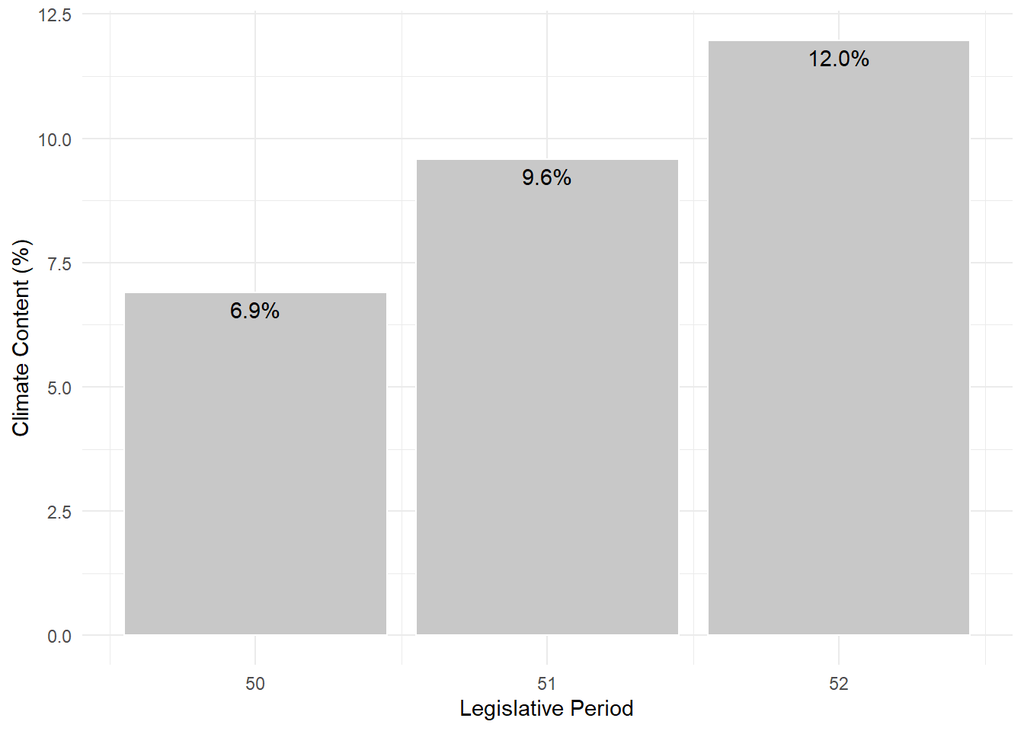

```r
period_climate_share <- paragraphs_classified_wide_final |>
  group_by(legislative_period) |>
  summarise(
    share_climate = sum(paragraph_word_count[final_climate == TRUE]) / sum(paragraph_word_count) * 100,
    .groups = "drop"
  )

p <- ggplot(period_climate_share, aes(x = legislative_period, y = share_climate)) +
  geom_col(fill = "#c8c8c8", color = "white") +
  labs(
    x = "Legislative Period",
    y = "Climate Content (%)"
  ) +
  # add geom text with percentage labels
  geom_text(aes(label =
    sprintf("%.1f%%", share_climate)),
    vjust = 1.5
  ) +
  theme_minimal()
ggsave(here("Outputs/05_plot_timeseries.png"))
write_rds(p, here("Outputs/05_plot_timeseries.rds"))
p
```

# Climate Discourse Across Parties

## Time-Fixed

First Question: How much of each party’s speech time do the parties devote to climate change? The grey line shows the parliament average at 9.0674216. In white are the percentages of climate speech in comparison to their total speech time.

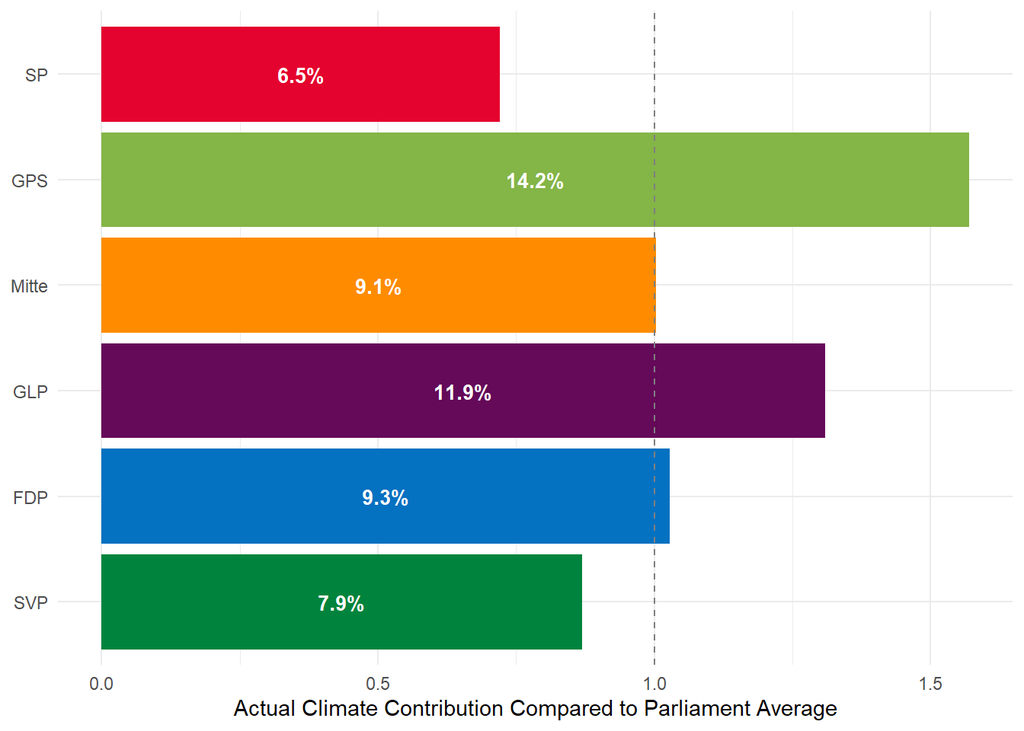

```r
p <- shares |>
  ggplot(aes(x = clim_intensity_ratio, y = party_abb, fill = party_abb)) +
  geom_col() +
  scale_fill_manual(values = party_colors) +
  geom_text(aes(label = ifelse(clim_share_in_party > 3,
                                sprintf("%.1f%%", clim_share_in_party),
                                "")),
            position = position_stack(vjust = 0.5),
            color = "white",
            fontface = "bold",
            size = 3.5) +
  labs(
    x = "Actual Climate Contribution Compared to Parliament Average",
    y = NULL
  ) +
  theme_minimal() +
  theme(legend.position = "none") +
  geom_vline(xintercept = 1, linetype = "dashed", color = "gray50")

ggsave(here("Outputs/05_plot_climate_factor_per_party.png"))
write_rds(p, here("Outputs/05_plot_climate_factor_per_party.rds"))
p
```

Second Question: Which parties dominate the climate discourse? I answer this question by showing each parties contribution to the total climate discourse. The second bar shows how the climate discourse would like if each party were of equal size.

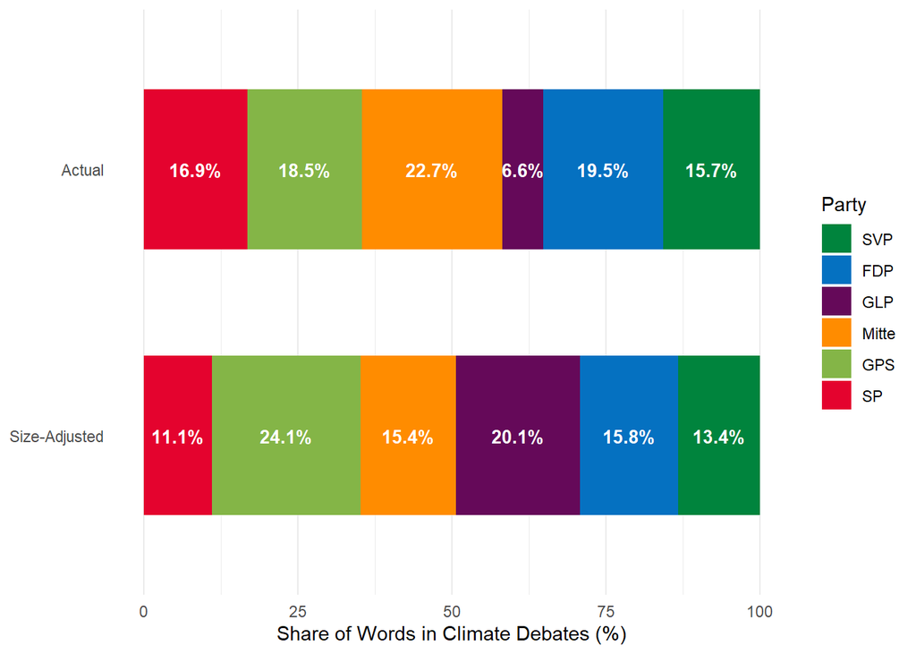

```r
# Reshape data for two bars
shares_long <- shares |>
  select(party_abb, size_adjusted_clim_share, party_share_in_clim) |>
  pivot_longer(
    cols = c(size_adjusted_clim_share, party_share_in_clim),
    names_to = "measure",
    values_to = "percentage"
  ) |>
  mutate(
    measure = factor(measure,
      levels = c("size_adjusted_clim_share", "party_share_in_clim"),
      labels = c("Size-Adjusted", "Actual"))
  )

p <- shares_long |>
  ggplot(aes(x = percentage, y = measure, fill = party_abb)) +
  geom_col(position = "stack", width = 0.6) +
  geom_text(aes(label = ifelse(percentage > 3,
    sprintf("%.1f%%", percentage),
    "")),
    position = position_stack(vjust = 0.5),
    color = "white",
    fontface = "bold",
    size = 3.5) +
  scale_fill_manual(values = party_colors) +
  labs(
    x = "Share of Words in Climate Debates (%)",
    y = NULL,
    fill = "Party"
  ) +
  theme_minimal() +
  theme(
    legend.position = "right",
    panel.grid.major.y = element_blank(),
    panel.grid.minor.y = element_blank()
  )

ggsave(here("Outputs/05_plot_climate_share_per_party.png"))
write_rds(p, here("Outputs/05_plot_climate_share_per_party.rds"))
p
```

## Time Variable

Share of climate-related speeches per parliamentary group over time. This means disregarding the total word count of each party. Just looking at the share of one party divided by the total word count of the climate debate in that session, without accounting for the fact that some parties speak more than others.

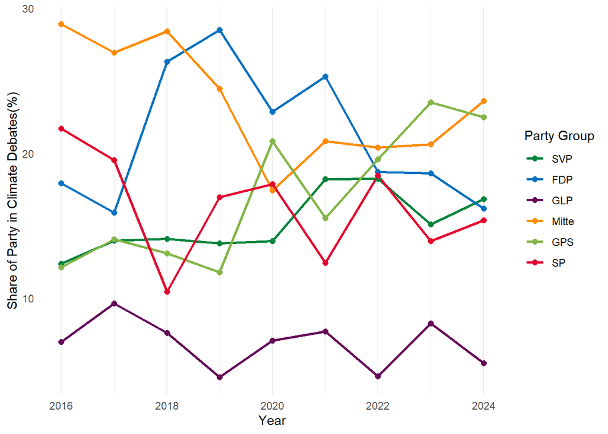

```r
p <- year_shares |>
  ggplot(aes(x = year, y = party_share_in_clim, color = party_abb)) +
  geom_line(aes(group = party_abb), size = 1) +
  geom_point(size = 2) +
  scale_color_manual(values = party_colors) +
  labs(
    x = "Year",
    y = "Share of Party in Climate Debates(%)",
    color = "Party Group"
  ) +
  theme_minimal() +
  theme(
    legend.position = "right",
    panel.grid.major.y = element_blank(),
    panel.grid.minor.y = element_blank()
  )
ggsave(here("Outputs/05_plot_climshare_timeseries.png"))
write_rds(p, here("Outputs/05_plot_climshare_timeseries.rds"))
p
```

How much of does a party contribute to the climate debate? This means how much of their total speech time do they devote to climate change, and how does this evolve over time?

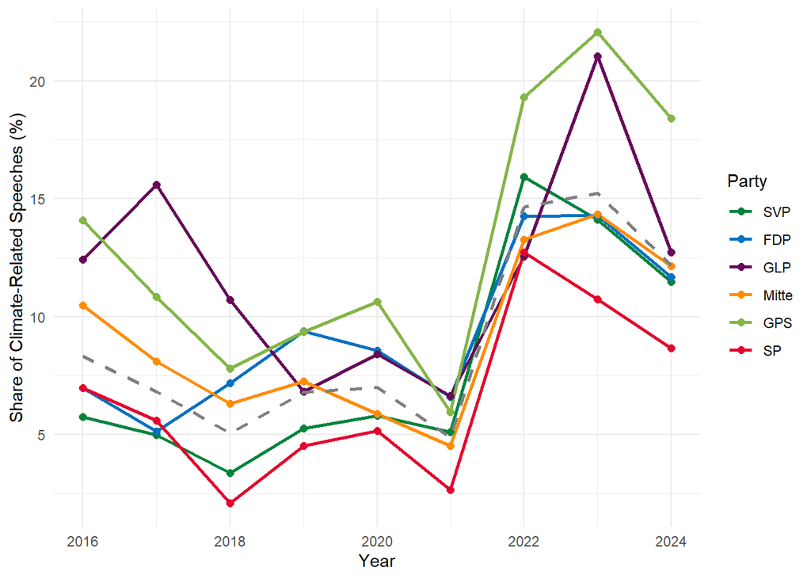

```r
# add the parliamentary average to the data and add it to the plot as a gry line
df_plot <- year_shares |>
  group_by(year) |>
  mutate(parl_avg_clim_share = sum(wordcount_party_clim) / sum(wordcount_party) * 100) |>
  ungroup()

# avg_label <- df_plot |>
#   group_by(year) |>
#   summarise(parl_avg_clim_share = sum(wordcount_party_clim) / sum(wordcount_party) * 100) |>
#   slice_max(year, n = 1)  # grab last year for label placement

p <- df_plot |>
  ggplot(aes(x = year, y = clim_share_in_party, color = party_abb)) +
  geom_line(aes(group = party_abb), size = 1) +
  geom_point(size = 2) +
  geom_line(aes(y = parl_avg_clim_share, group = 1), color = "gray50", linetype = "dashed", size = 1) +
  # geom_text(
  #   data = avg_label,
  #   aes(x = year, y = parl_avg_clim_share, label = "Parliament avg."),
  #   color = "gray50",
  #   hjust = -0.1,  # nudge right of the last point
  #   vjust = 0.5,
  #   size = 3.5,
  #   inherit.aes = FALSE
  # ) +
  scale_color_manual(values = party_colors) +
  # coord_cartesian(clip = "off") +  # allows text to render outside plot area
  labs(
    x = "Year",
    y = "Share of Climate-Related Speeches (%)",
    color = "Party"
  ) +
  theme_minimal() #+
  # theme(
  #   legend.position = "right",
  #   panel.grid.major.y = element_blank(),
  #   panel.grid.minor.y = element_blank(),
  #   plot.margin = margin(5, 60, 5, 5)  # extra right margin for the label
  # )
ggsave(here("Outputs/05_plot_partyshare_timeseries.png"))
write_rds(p, here("Outputs/05_plot_partyshare_timeseries.rds"))
p
```